# Differential expression analysis of mouse somites

23 May 2019

```r
meta <- read.table(paste0(dir, "RNA-seq/data/metadata_RNAseq.tsv"), stringsAsFactors = FALSE, header = TRUE)
meta <- meta[meta$use==1,]

data <- read.table(paste0(dir, "RNA-seq/data/geneCounts.RAW.tsv"))
y <- readRDS(paste0(dir, "RNA-seq/results/01_edgeRobject.Rds"))
```

We have RNA-seq data from 76 single mouse somites, spanning six different developmental stages. Data has been normalised for sequencing depth and composition biases (using `edgeR`). We noted strong batch effects from sample collection date. To perform differential expression correctly, we need to control for these technical effects. However, since the experimental design is partially confounded with the collection date, we needed to use alternative methods to identify the technical effects, instead of simply blocking on batch. We have tried two different approaches:

- Surrogate variable analysis: identifies 11 surrogate variables, the first strongly correlated with collection date.
- PCA on the residuals of the model containing the somite-stage information.

Both approaches result in successful removal of the collection date effect, and enhance the separation by stage and somite. So we can use these to control for technical effects and, at the same time, enhance our statistical power to determine differences across somites and stages.

As a baseline, we will perform the differential analysis without any correction. We can then compare these results to those obtained when incorporating the SVA or PCA covariates, to see if they are indeed removing technical noise or instead are capturing biological signal.

### Differential expression analysis

We can test for differences between the somite trios and between stages.

We use `edgeR` to perform the differential testing. We first estimate the dispersion and fit the design containing the interaction of somite and stage.

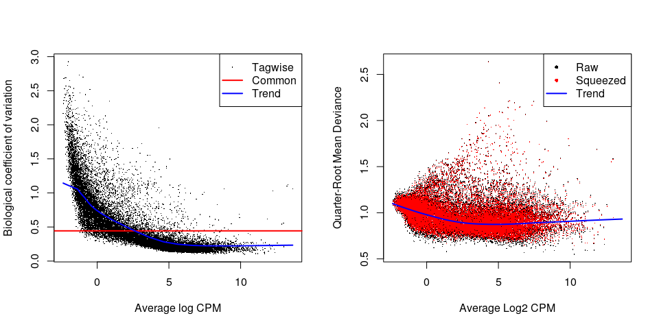

```r
## design
meta$group <- as.factor(meta$group)
design <- model.matrix(~0+group, meta)
colnames(design) <- paste0("stage",levels(meta$group))

## dispersion
y <- estimateDisp(y, design, robust = TRUE)
par(mfrow=c(1,2))
plotBCV(y)

## fit model
fit <- glmQLFit(y, design, robust=TRUE)
plotQLDisp(fit)
```

```r
# summary(fit$df.prior)

saveRDS(y, file=paste0(dir, "RNA-seq/results/03.1_edgeRobject.Rds"))
```

#### Differences across somite trios

We test whether gene expression changes as somites differentiate, by testing for differences between somite I, II and III. We have at least 3 replicates for each stage-somite combination, so we should have decent power.

```r
table(meta$stage, meta$somite)
```

```
##
##      SI SII SIII
##   8   4   4    4
##   18  5   5    5
##   21  4   3    4
##   25  4   3    4
##   27  4   4    3
##   35  6   4    6
```

The changes could be conserved across development, or stage specific.

First, we test on a per-stage basis. And we test all three pairwise comparisons from each stage at once with an anova-like test, to avoid over testing. Thus, anything with an adjusted p-value lower than 0.05 is DE between at least a pair of somites. For all stages there are very few genes that reach significance.

```r
my.contrasts <- makeContrasts(stage8.IIvsI=stage8.SII-stage8.SI, stage8.IIIvsI=stage8.SIII-stage8.SI,
                              stage8.IIIvsII=stage8.SIII-stage8.SII,
                              stage18.IIvsI=stage18.SII-stage18.SI, stage18.IIIvsI=stage18.SIII-stage18.SI,
                              stage18.IIIvsII=stage18.SIII-stage18.SII,
                              stage21.IIvsI=stage21.SII-stage21.SI, stage21.IIIvsI=stage21.SIII-stage21.SI,
                              stage21.IIIvsII=stage21.SIII-stage21.SII,
                              stage25.IIvsI=stage25.SII-stage25.SI, stage25.IIIvsI=stage25.SIII-stage25.SI,
                              stage25.IIIvsII=stage25.SIII-stage25.SII,
                              stage27.IIvsI=stage27.SII-stage27.SI, stage27.IIIvsI=stage27.SIII-stage27.SI,
                              stage27.IIIvsII=stage27.SIII-stage27.SII,
                              stage35.IIvsI=stage35.SII-stage35.SI, stage35.IIIvsI=stage35.SIII-stage35.SI,
                              stage35.IIIvsII=stage35.SIII-stage35.SII, levels=design)

## test
stage8 <- glmQLFTest(fit, contrast = my.contrasts[,1:3])
stage18 <- glmQLFTest(fit, contrast = my.contrasts[,4:6])
stage21 <- glmQLFTest(fit, contrast = my.contrasts[,7:9])
stage25 <- glmQLFTest(fit, contrast = my.contrasts[,10:12])
stage27 <- glmQLFTest(fit, contrast = my.contrasts[,13:15])
stage35 <- glmQLFTest(fit, contrast = my.contrasts[,16:18])

## results
stage8 <- as.data.frame(topTags(stage8, n=Inf))
stage18 <- as.data.frame(topTags(stage18, n=Inf))
stage21 <- as.data.frame(topTags(stage21, n=Inf))
stage25 <- as.data.frame(topTags(stage25, n=Inf))
stage27 <- as.data.frame(topTags(stage27, n=Inf))
stage35 <- as.data.frame(topTags(stage35, n=Inf))

fdr_thr <- 0.05
nDE <- t(data.frame(stage8=nrow(stage8[stage8$FDR<fdr_thr,]), stage18=nrow(stage18[stage18$FDR<fdr_thr,]),
                    stage21=nrow(stage21[stage21$FDR<fdr_thr,]), stage25=nrow(stage25[stage25$FDR<fdr_thr,]),
                    stage27=nrow(stage27[stage27$FDR<fdr_thr,]), stage35=nrow(stage35[stage35$FDR<fdr_thr,])))
colnames(nDE) <- "numberDE"
nDE
```

```
##         numberDE
## stage8        20
## stage18        6
## stage21        0
## stage25        0
## stage27        5
## stage35        8
```

To increase power, we can now test the average of all somites across stages. This will detect changes that are conserved across development but miss any stage-specific changes. The increased power from having a lot of replicates results in a higher number of significant genes between somites I and II and, mostly, between somites I and III. Nonetheless, the changes are still subtle (perhaps not surprisingly).

```r
my.contrasts <- makeContrasts(
  somiteIIvsI = (stage8.SII + stage18.SII + stage21.SII + stage25.SII + stage27.SII + stage35.SII)/6 - (stage8.SI + stage18.SI + stage21.SI + stage25.SI + stage27.SI + stage35.SI)/6,
  somiteIIIvsI = (stage8.SIII + stage18.SIII + stage21.SIII + stage25.SIII + stage27.SIII + stage35.SIII)/6 - (stage8.SI + stage18.SI + stage21.SI + stage25.SI + stage27.SI + stage35.SI)/6,
  somiteIIIvsII = (stage8.SIII + stage18.SIII + stage21.SIII + stage25.SIII + stage27.SIII + stage35.SIII)/6 - (stage8.SII + stage18.SII + stage21.SII + stage25.SII + stage27.SII + stage35.SII)/6,
  levels=design)

somiteIIvsI.all <- glmQLFTest(fit, contrast = my.contrasts[,"somiteIIvsI"])
somiteIIIvsI.all <- glmQLFTest(fit, contrast = my.contrasts[,"somiteIIIvsI"])
somiteIIIvsII.all <- glmQLFTest(fit, contrast = my.contrasts[,"somiteIIIvsII"])

## data.frames
somiteIIvsI.all <- as.data.frame(topTags(somiteIIvsI.all, n=Inf))
somiteIIIvsI.all <- as.data.frame(topTags(somiteIIIvsI.all, n=Inf))
somiteIIIvsII.all <- as.data.frame(topTags(somiteIIIvsII.all, n=Inf))

nDE <- data.frame(IvsII = nrow(somiteIIvsI.all[somiteIIvsI.all$FDR < fdr_thr,]), IIvsIII = nrow(somiteIIIvsII.all[somiteIIIvsII.all$FDR < fdr_thr,]), IvsIII = nrow(somiteIIIvsI.all[somiteIIIvsI.all$FDR < fdr_thr,]))
row.names(nDE) <- c("all")
t(nDE)
```

```
##         all
## IvsII    95
## IIvsIII   3
## IvsIII  700
```

At first glance, we can see several genes significantly changing congruently in both comparisons, which suggest changes are gradual and get bigger as differentiation proceeds.

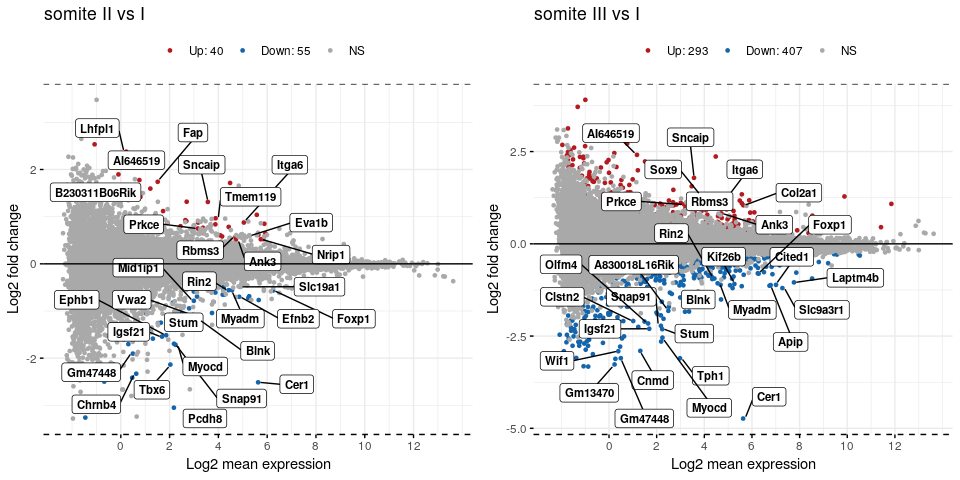

```r
plots <- list()

tmp <- somiteIIvsI.all
colnames(tmp)[c(2,3,6)] <- c("log2FoldChange","baseMean","padj")
tmp$baseMean <- 2^tmp$baseMean-1
plots[[1]] <- ggmaplot(tmp, FDR = fdr_thr, fc=0, genenames = tmp$genes, size=1, legend = "top", top=30, label.rectangle = TRUE, select.top.method = "padj", font.label = c("bold", 9), main="somite II vs I", ggtheme = theme_minimal() )

tmp <- somiteIIIvsI.all
colnames(tmp)[c(2,3,6)] <- c("log2FoldChange","baseMean","padj")
tmp$baseMean <- 2^tmp$baseMean-1
plots[[2]] <- ggmaplot(tmp, FDR = fdr_thr, fc=0, genenames = tmp$genes, size=1, legend = "top", top=30, label.rectangle = TRUE, select.top.method = "padj", font.label = c("bold", 9), main="somite III vs I ", ggtheme = theme_minimal() )

multiplot(plotlist = plots, cols=2)
```

There are 90 genes significant in both comparisons, which means that the changes of somite IvsII are just a subset of IvsIII. And this suggests that changes are small and progressive, and are only big enough between somites I and III to become significant. This is certainly true for the most significant changes.

```r
dataNorm <- read.table(paste0(dir, "RNA-seq/data/geneCounts.NORM_logCPM.tsv"))

retrieveGeneExpr <- function(dataNorm, meta, columns=c("stage", "somite", "date"), gene){
  d <- t(as.data.frame(dataNorm[dataNorm$gene==gene,-1]))
  stopifnot(identical(row.names(d), meta$sample))
  d <- cbind(d, meta[,columns])
  colnames(d)[1] <- "count"
  return(d)
}
```

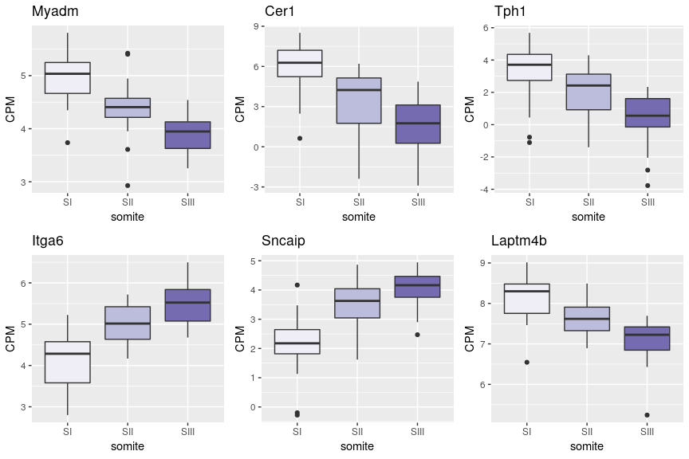

```r
plots <- list()
tmp <- somiteIIIvsI.all[somiteIIIvsI.all$FDR<0.05,1]
for(i in 1:6){
  d <- retrieveGeneExpr(dataNorm, meta, gene=tmp[i])
  plots[[i]] <- ggplot(d, aes(x=somite, y=count)) + geom_boxplot(aes(fill=somite)) + scale_fill_brewer(palette = "Purples") + ggtitle(tmp[i]) + theme(legend.position="none") + ylab("CPM")
}
multiplot(plotlist = plots, cols=3)
```

#### Differences across developmental stages

We can also test for changes as development proceeds. Again, we can check first if there are any changes that happen differently in somite I, II or III. So we test whether any pairwise comparison between any two stages is significant, per somite. Around 1,500 genes are changing across time, when taking the data from each somite level.

```r
my.contrasts <- makeContrasts(stage8vs18 = stage18.SI - stage8.SI, stage8vs21 = stage21.SI - stage8.SI,
                              stage8vs25 = stage25.SI - stage8.SI, stage8vs27 = stage27.SI - stage8.SI,
                              stage8vs35 = stage35.SI - stage8.SI,
                              stage18vs21 = stage21.SI - stage18.SI, stage18vs25 = stage25.SI - stage18.SI,
                              stage18vs27 = stage27.SI - stage18.SI, stage18vs35 = stage35.SI - stage18.SI,
                              stage21vs25 = stage25.SI - stage21.SI, stage21vs27 = stage27.SI - stage21.SI,
                              stage21vs35 = stage35.SI - stage21.SI,
                              stage25vs27 = stage27.SI - stage25.SI, stage25vs35 = stage35.SI - stage25.SI,
                              stage27vs35 = stage35.SI - stage27.SI, levels=design)
test <- glmQLFTest(fit, contrast = my.contrasts)
somiteI <- as.data.frame(topTags(test, n=Inf))

my.contrasts <- makeContrasts(stage8vs18 = stage18.SII - stage8.SII, stage8vs21 = stage21.SII - stage8.SII,
                              stage8vs25 = stage25.SII - stage8.SII, stage8vs27 = stage27.SII - stage8.SII,
                              stage8vs35 = stage35.SII - stage8.SII,
                              stage18vs21 = stage21.SII - stage18.SII, stage18vs25 = stage25.SII - stage18.SII,
                              stage18vs27 = stage27.SII - stage18.SII, stage18vs35 = stage35.SII - stage18.SII,
                              stage21vs25 = stage25.SII - stage21.SII, stage21vs27 = stage27.SII - stage21.SII,
                              stage21vs35 = stage35.SII - stage21.SII,
                              stage25vs27 = stage27.SII - stage25.SII, stage25vs35 = stage35.SII - stage25.SII,
                              stage27vs35 = stage35.SII - stage27.SII, levels=design)
test <- glmQLFTest(fit, contrast = my.contrasts)
somiteII <- as.data.frame(topTags(test, n=Inf))

my.contrasts <- makeContrasts(stage8vs18 = stage18.SIII - stage8.SIII, stage8vs21 = stage21.SIII - stage8.SIII,
                              stage8vs25 = stage25.SIII - stage8.SIII, stage8vs27 = stage27.SIII - stage8.SIII,
                              stage8vs35 = stage35.SIII - stage8.SIII,
                              stage18vs21 = stage21.SIII - stage18.SIII, stage18vs25 = stage25.SIII - stage18.SIII,
                              stage18vs27 = stage27.SIII - stage18.SIII, stage18vs35 = stage35.SIII - stage18.SIII,
                              stage21vs25 = stage25.SIII - stage21.SIII, stage21vs27 = stage27.SIII - stage21.SIII,
                              stage21vs35 = stage35.SIII - stage21.SIII,
                              stage25vs27 = stage27.SIII - stage25.SIII, stage25vs35 = stage35.SIII - stage25.SIII,
                              stage27vs35 = stage35.SIII - stage27.SIII, levels=design)
test <- glmQLFTest(fit, contrast = my.contrasts)
somiteIII <- as.data.frame(topTags(test, n=Inf))

nDE <- t(data.frame(somiteI=nrow(somiteI[somiteI$FDR < fdr_thr,]), somiteII=nrow(somiteII[somiteII$FDR < fdr_thr,]), somiteIII=nrow(somiteIII[somiteIII$FDR < fdr_thr,])))
colnames(nDE) <- "numberDE"
nDE
```

```
##           numberDE
## somiteI       1412
## somiteII      1585
## somiteIII     1758
```

Despite the similar numbers for the three somite levels, there are plenty of genes identified in only one of them, although there is a good core of genes identified in all comparisons.

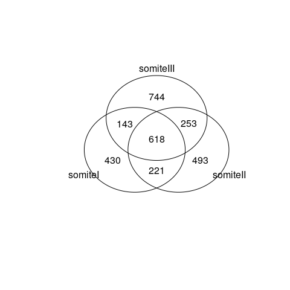

```r
venn(data=list(somiteI=row.names(somiteI[somiteI$FDR < fdr_thr,]), somiteII=row.names(somiteII[somiteII$FDR < fdr_thr,]), somiteIII=row.names(somiteIII[somiteIII$FDR < fdr_thr,])))
```

Alternatively, we use the somite trios as replicates (which is not unreasonable given the small number of DE genes between them) to increase power. In this case, genes with an adjusted p-value lower than 0.05 are DE between any pair of stages. We get nearly 8 thousand significant genes.

```r
my.contrasts <- makeContrasts(stage8vs18 = (stage18.SIII+stage18.SII+stage18.SI)/3 - (stage8.SIII+stage8.SII+stage8.SI)/3,
                              stage8vs21 = (stage21.SIII+stage21.SII+stage21.SI)/3 - (stage8.SIII+stage8.SII+stage8.SI)/3,
                              stage8vs25 = (stage25.SIII+stage25.SII+stage25.SI)/3 - (stage8.SIII+stage8.SII+stage8.SI)/3,
                              stage8vs27 = (stage27.SIII+stage27.SII+stage27.SI)/3 - (stage8.SIII+stage8.SII+stage8.SI)/3,
                              stage8vs35 = (stage35.SIII+stage35.SII+stage35.SI)/3 - (stage8.SIII+stage8.SII+stage8.SI)/3,
                              stage18vs21 = (stage21.SIII+stage21.SII+stage21.SI)/3 - (stage18.SIII+stage18.SII+stage18.SI)/3,
                              stage18vs25 = (stage25.SIII+stage25.SII+stage25.SI)/3 - (stage18.SIII+stage18.SII+stage18.SI)/3,
                              stage18vs27 = (stage27.SIII+stage27.SII+stage27.SI)/3 - (stage18.SIII+stage18.SII+stage18.SI)/3,
                              stage18vs35 = (stage35.SIII+stage35.SII+stage35.SI)/3 - (stage18.SIII+stage18.SII+stage18.SI)/3,
                              stage21vs25 = (stage25.SIII+stage25.SII+stage25.SI)/3 - (stage21.SIII+stage21.SII+stage21.SI)/3,
                              stage21vs27 = (stage27.SIII+stage27.SII+stage27.SI)/3 - (stage21.SIII+stage21.SII+stage21.SI)/3,
                              stage21vs35 = (stage35.SIII+stage35.SII+stage35.SI)/3 - (stage21.SIII+stage21.SII+stage21.SI)/3,
                              stage25vs27 = (stage27.SIII+stage27.SII+stage27.SI)/3 - (stage25.SIII+stage25.SII+stage25.SI)/3,
                              stage25vs35 = (stage35.SIII+stage35.SII+stage35.SI)/3 - (stage25.SIII+stage25.SII+stage25.SI)/3,
                              stage27vs35 = (stage35.SIII+stage35.SII+stage35.SI)/3 - (stage27.SIII+stage27.SII+stage27.SI)/3, levels=design)

test <- glmQLFTest(fit, contrast = my.contrasts)
all <- as.data.frame(topTags(test, n=Inf))
nrow(all[all$FDR < 0.05,])
```

```
## [1] 7843
```

Importantly, almost all (>94.6%) of the genes identified in the somite-specific analyses are identified in this *averaged* test. Thus, the differences before are probably due to lack of power, and not to somite-specific changes.

```r
sI <- row.names(somiteI[somiteI$FDR < fdr_thr,])
sII <- row.names(somiteII[somiteII$FDR < fdr_thr,])
sIII <- row.names(somiteIII[somiteIII$FDR < fdr_thr,])
ave <- row.names(all[all$FDR < fdr_thr,])

# length(intersect(ave, sI))/length(sI)*100 # 98.44
# length(intersect(ave, sII))/length(sII)*100 # 98.86
# length(intersect(ave, sIII))/length(sIII)*100 # 94.6
```

We do not have a p-value for each pair-wise comparison so we cannot split the genes into which are significant for each pair/groups of stages. However, we can use the fold-change as a proxy for whether the gene is likely to be DE in each comparison. Counting the number of genes with an absolute fold-change of ~1.5 or more gives us an idea of the magnitude of changes between stages.

```r
all.fc <- all
all.fc <- all.fc[all.fc$FDR < 0.05,]
all.fc[,2:16] <- t(apply(all.fc[,2:16], 1, function(x) ifelse(abs(x)>=0.6,1,0)))

tmp <- colSums(all.fc[,2:16])
data.frame(stage8=tmp[1:5], stage18=c("",tmp[6:9]), stage21=c("","",tmp[10:12]), stage25=c("","","",tmp[13:14]), stage27=c("","","","",tmp[15]))
```

```
##                  stage8 stage18 stage21 stage25 stage27
## logFC.stage8vs18   2542
## logFC.stage8vs21   3014    1958
## logFC.stage8vs25   3661    2372    1695
## logFC.stage8vs27   3915    2862    3169    2888
## logFC.stage8vs35   4345    3153    3130    2833    2198
```

This is promising, suggesting there are small but consistent differences in a restricted set of genes as somites differentiate; and a much larger set of genes changing as development progresses.

```r
# somite trios, per stage
write.table(stage8, paste0(dir, "RNA-seq/results/03.1_DEresults_somiteTrios_stage8.tsv"), quote = FALSE, sep="\t")
write.table(stage18, paste0(dir, "RNA-seq/results/03.1_DEresults_somiteTrios_stage18.tsv"), quote = FALSE, sep="\t")
write.table(stage21, paste0(dir, "RNA-seq/results/03.1_DEresults_somiteTrios_stage21.tsv"), quote = FALSE, sep="\t")
write.table(stage25, paste0(dir, "RNA-seq/results/03.1_DEresults_somiteTrios_stage25.tsv"), quote = FALSE, sep="\t")
write.table(stage27, paste0(dir, "RNA-seq/results/03.1_DEresults_somiteTrios_stage27.tsv"), quote = FALSE, sep="\t")
write.table(stage35, paste0(dir, "RNA-seq/results/03.1_DEresults_somiteTrios_stage35.tsv"), quote = FALSE, sep="\t")

# somite trios, average
write.table(somiteIIvsI.all, paste0(dir, "RNA-seq/results/03.1_DEresults_somiteTrios_somiteIvsII.tsv"), quote = FALSE, sep="\t")
write.table(somiteIIIvsII.all, paste0(dir, "RNA-seq/results/03.1_DEresults_somiteTrios_somiteIIvsIII.tsv"), quote = FALSE, sep="\t")
write.table(somiteIIIvsI.all, paste0(dir, "RNA-seq/results/03.1_DEresults_somiteTrios_somiteIvsIII.tsv"), quote = FALSE, sep="\t")

# stage, per somite
write.table(somiteI, paste0(dir, "RNA-seq/results/03.1_DEresults_stage_somiteI.tsv"), quote = FALSE, sep="\t")
write.table(somiteII, paste0(dir, "RNA-seq/results/03.1_DEresults_stage_somiteII.tsv"), quote = FALSE, sep="\t")
write.table(somiteIII, paste0(dir, "RNA-seq/results/03.1_DEresults_stage_somiteIII.tsv"), quote = FALSE, sep="\t")

# stage, aveerage
write.table(all, paste0(dir, "RNA-seq/results/03.1_DEresults_stage_all.tsv"), quote = FALSE, sep="\t")
```